# TextMiningTwitter

Juan Garcia Ruiz

14 de mayo de 2019

```
## [1] "Using direct authentication"
```

Vamos a realizar un analisis de los tweets que hablen sobre el cambio climatico.

Para ello, primero obtendremos de Twitter los tweets que contengan el hashtag **#CambioClimatico**:

```r
if(!file.exists("./climateChangeTweets.csv")){
  tweets <- searchTwitter("#CambioClimatico", n = 6000)
  tweets.data.frame <- ldply(tweets, function(l) l$toDataFrame())
  write.csv(tweets.data.frame, file = "climateChangeTweets.csv")
}else{
  tweets.data.frame <- read.csv("climateChangeTweets.csv")
}
```

Visualizamos los primeros tweets que tenemos guardados:

```r
head(tweets.data.frame)
```

```
##   X
## 1 1
## 2 2
## 3 3
## 4 4
## 5 5
## 6 6
##                                                                                                                                                                                                                                  text
## 1                                                                  RT @san_lunag: Hoy comienza un importante capítulo para la política ambiental de 🇲🇽. La @SEMARNAT_mx firma un importante convenio de colabo
## 2                                                                                       RT @ecointeligencia: La lucha contra el #CambioClimatico obliga a cambiar el organigrama de todas las administraciones públicas\nhttps://t.c
## 3                                                                          RT @CamiloPrietoVal: ⚠Atención⚠ Las elevadas emisiones de CO2 nos están llevando a un #CambioClimático riesgoso. La última medición de @NOA
## 4 RT @FAOMexico: Apoya a los productores locales 🙋‍♀🙋‍♂🌎\n\n👉 https://t.co/XGirViWuFk 👈\n#AccionesPorElClima\n#CambioClimático https://t.co/asTjW
## 5                                                                                        RT @MiEstrellaDeMar: "Sanitarios por el planeta.- Llamamiento mundial exhorta a estos profesionales a actuar sobre la salud planetaria desd
## 6                                                                                       RT @carovera_ar: Expertos del @IPCC_CH revisaron la  metodología para medir gases de efecto invernadero. \n\nHay que medir bien para evaluar
##   favorited favoriteCount replyToSN             created truncated
```

[output cut: 27 more lines]

Veamos el número total de tweets que tenemos, o lo que es lo mismo, el número de filas que tiene nuestro dataframe:

```r
nrow(tweets.data.frame)
```

```
## [1] 6000
```

También sería interesante saber cuantos usuarios han participado:

```r
unique.Users <- unique(tweets.data.frame$screenName)
length(unique.Users)
```

```
## [1] 4598
```

```r
duplicated.Users <- duplicated(tweets.data.frame$screenName)
length(duplicated.Users[duplicated.Users == TRUE])
```

```
## [1] 1402
```

Hay que tener en cuenta que no todos los tweets que aparecen son tweets originales, mucho de estos pueden ser retweet. Veamos cuantos lo son:

```r
length(tweets.data.frame$isRetweet[tweets.data.frame$isRetweet == TRUE])
```

```
## [1] 4422
```

Vemos que casi tres cuartas partes de los tweets recogidos son RTs.

Ahora veremos cuantos de los tweets han sido retweeteados:

```r
length(tweets.data.frame$retweeted[tweets.data.frame$retweeted == TRUE])
```

```
## [1] 0
```

Por algun motivo devuelve 0, podriamos pensar que es porque solo se fija en los tweets originales y no los retweets pero existen tweets originales con retweets.

```r
# No existe ninguna columna en el dataframe relacionado con el idioma.
```

Nos interesa ahora saber cuales son los 10 usuarios que más han participado:

```r
tweets.data.frame %>% group_by(screenName) %>% summarize(n=n()) %>% arrange(desc(n)) %>% top_n(10)
```

```
## # A tibble: 10 x 2
##    screenName          n
##    <fct>           <int>
##  1 VetrepreneurOne   176
##  2 jochanto           26
##  3 100CoNeutral       25
##  4 pablonegri         18
##  5 inspiractionorg    15
##  6 drotorrent         13
##  7 iSostenibilidad    13
##  8 SandorGerendasK    12
##  9 ApunteIndicado     10
## 10 AmigosTierraEsp     9
```

Tras echar un vistazo, vemos que el usuario **VetrepreneurOne** tiene una gran cantidad de interacciones con ese hashtag. Solo tenemos que meternos en su perfil para ver que es un bot que usa el hashtag para publicar cualquier cosa aunque no tenga nada que ver. Lo adecuado sería por tanto eliminarlo del dataframe:

```r
bot.tweets <- filter(tweets.data.frame, tweets.data.frame$screenName == "VetrepreneurOne")
tweets.data.frame <- anti_join(tweets.data.frame, bot.tweets)
```

Quizas deberiamos fijarnos en aquellos tweets que más repercusión han tenido, miremos los tweets que hayan tenido mas de 5 retweets:

```r
popular.tweets <- as.data.frame(filter(tweets.data.frame,retweetCount > 5))
nrow(popular.tweets)
```

```
## [1] 3814
```

Como vemos, hay una gran cantidad de tweets que han sido retweeteado más de 5 veces.

# 1 Text Mining

## 1.1 Pre-procesamiento

Lo primero que deberíamos hacer es, quizás, eliminar los retweets. Creo que al fin y al cabo los retweet contaminan más de lo que aportan a la hora de realizar este analisis ya que podría aparecer repetido o ser un tweet que usa el hashtag pero que, aunque sea muy retweeteado, no hable de eso.

```r
tweets.data.frame <- filter(tweets.data.frame, tweets.data.frame$isRetweet == FALSE)
nrow(tweets.data.frame)
```

```
## [1] 1402
```

Como vemos el número de tweets se ha reducido de manera considerable.

A continuación, eliminaremos elementos del tweet que no nos interese. Por ejemplo, los hashtag y las menciones:

```r
tweets.data.frame$text <- stringr::str_replace_all(tweets.data.frame$text, "@\\w+"," ")
tweets.data.frame$text <- stringr::str_replace_all(tweets.data.frame$text, "#\\S+"," ")
```

También todos los links:

```r
tweets.data.frame$text <- stringr::str_replace_all(tweets.data.frame$text, "http\\S+\\s*"," ")
tweets.data.frame$text <- stringr::str_replace_all(tweets.data.frame$text, "http[[:alnum:]]*"," ")
tweets.data.frame$text <- stringr::str_replace_all(tweets.data.frame$text, "http[[\\b+RT]]"," ")
```

Tras esto deberemos tener también cuidado con los caracteres especiales como las vocales con tilde o la letra **ñ**:

```r
tweets.data.frame$text <- stringr::str_replace_all(tweets.data.frame$text, "[à|á]", "a")
tweets.data.frame$text <- stringr::str_replace_all(tweets.data.frame$text, "[è|é]", "e")
tweets.data.frame$text <- stringr::str_replace_all(tweets.data.frame$text, "[ì|í]", "i")
tweets.data.frame$text <- stringr::str_replace_all(tweets.data.frame$text, "[ò|ó]", "o")
tweets.data.frame$text <- stringr::str_replace_all(tweets.data.frame$text, "[ù|ú]", "u")
tweets.data.frame$text <- stringr::str_replace_all(tweets.data.frame$text, "[ñ]", "n")
```

Aunque seguramente los tweets esten en español, no esta mal eliminar también la **ç**:

```r
tweets.data.frame$text <- stringr::str_replace_all(tweets.data.frame$text, "[ç]", "c")
```

Para acabar con la eliminación de caracteres, vamos a eliminar simbolos de puntuación, exclamación…; los objetos invisibles y, además, los emojis:

```r
tweets.data.frame$text <- stringr::str_replace_all(tweets.data.frame$text, "[¡!?¿()/]", "")
tweets.data.frame$text <- stringr::str_replace_all(tweets.data.frame$text, "[-']", " ")
tweets.data.frame$text <- stringr::str_replace_all(tweets.data.frame$text, "[[:punct:]]", "")
tweets.data.frame$text <- stringr::str_replace_all(tweets.data.frame$text, "[\r\n]", "")
tweets.data.frame$text <- unlist(lapply(tweets.data.frame$text, function(c) iconv(c, "latin1", "ASCII", sub="")))
```

Tras todos estos preparatorios, procedemos a convertir los textos procesados en un corpus y lo ponemos en misnusculas:

```r
tweetCorpus <- Corpus(VectorSource(tweets.data.frame$text))
tweetCorpus <- tm_map(tweetCorpus, function(x) iconv(enc2utf8(x), sub = "byte"))
tweetCorpus <- tm_map(tweetCorpus, content_transformer(tolower))
```

A continuación eliminamos los números, signos de puntuación y espacios en blanco:

```r
tweetCorpus <- tm_map(tweetCorpus, removeNumbers)
tweetCorpus <- tm_map(tweetCorpus, removePunctuation)
tweetCorpus <- tm_map(tweetCorpus, stripWhitespace)
```

Por último, eliminaremos palabras inútiles y algunas palabras extras que aparecen en el wordcloud que nos parecen poco relevantes:

```r
tweetCorpus <- tm_map(tweetCorpus, removeWords, stopwords("spanish"))
tweetCorpus <- tm_map(tweetCorpus, removeWords, c("sera","mas","ufcc","uff","debido","quedaran","anos","hacer","via","dia","the","cada","hoy","ser","ufd","puede","solo","asi","hace","vez","segun","estan","ufe","ufa","ano","ver", "sgk", "cop"))
```

## 1.2 Generación DTM

```r
dtm <- DocumentTermMatrix(tweetCorpus)
dtm
```

```
## <<DocumentTermMatrix (documents: 1402, terms: 3705)>>
## Non-/sparse entries: 8658/5185752
## Sparsity           : 100%
## Maximal term length: 43
## Weighting          : term frequency (tf)
```

Obtenemos ahora las frecuancias de las palabras y mostramos las que más aparecen:

```r
freq <- colSums(as.matrix(dtm))
ord <- order(freq)
freq[tail(ord)]
```

```
##       capital     climatico derretimiento        cambio       planeta
##            64            66            86            87            88
##     glaciares
##            88
```

Como podemos intuir, no todas las palabras recogidas nos pueden interesar. Las palabras menos comunes no requieren de nuestra atención para hacer el estudio.

Lo que haremos es obtener la media de la frecuencia de aparición de las palabras, nos quedaremos con aquellas cuya frecuencia sea mayor y finalmente lo ordenaremos el dataframe creado de más a menos frecuente:

```r
freq.mean <- mean(freq[ord])
freq.mean
```

```
## [1] 2.354656
```

```r
freq.data.frame <- data.frame(name = names(freq), freq = freq)
freq.data.frame <- filter(freq.data.frame, freq > freq.mean)
freq.data.frame <- arrange(freq.data.frame, desc(freq))
head(freq.data.frame,20)
```

```
##             name freq
## 1        planeta   88
## 2      glaciares   88
## 3         cambio   87
## 4  derretimiento   86
## 5      climatico   66
## 6         global   64
## 7        capital   64
## 8      hundiendo   62
## 9           cara   61
## 10     indonesia   60
## 11     reubicada   60
## 12 calentamiento   59
## 13       noticia   58
## 14         culpa   56
## 15          mala   56
## 16     bebedores   55
## 17       cerveza   55
## 18        escasa   55
## 19         hielo   52
## 20          agua   51
```

Para visualizar estos datos mejor vamos a ponerlos en un grafico. Como son muchos terminos, pondremos los 30 mas importantes:

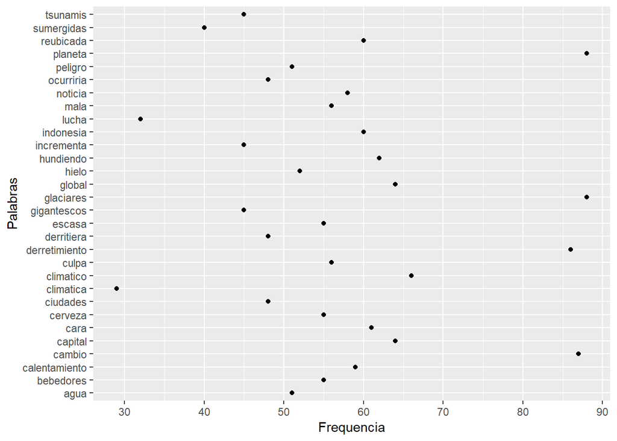

```r
ggplot(head(freq.data.frame,30)) + geom_point(aes(y = head(freq.data.frame$name,30), x = head(freq.data.frame$freq,30))) + ylab("Palabras") + xlab("Frequencia")
```

Ahora generaremos varios wordclouds con la información que hemos obtenido. Primero usaremos la biblioteca **wordcloud** aunque no nos permita guardarlo:

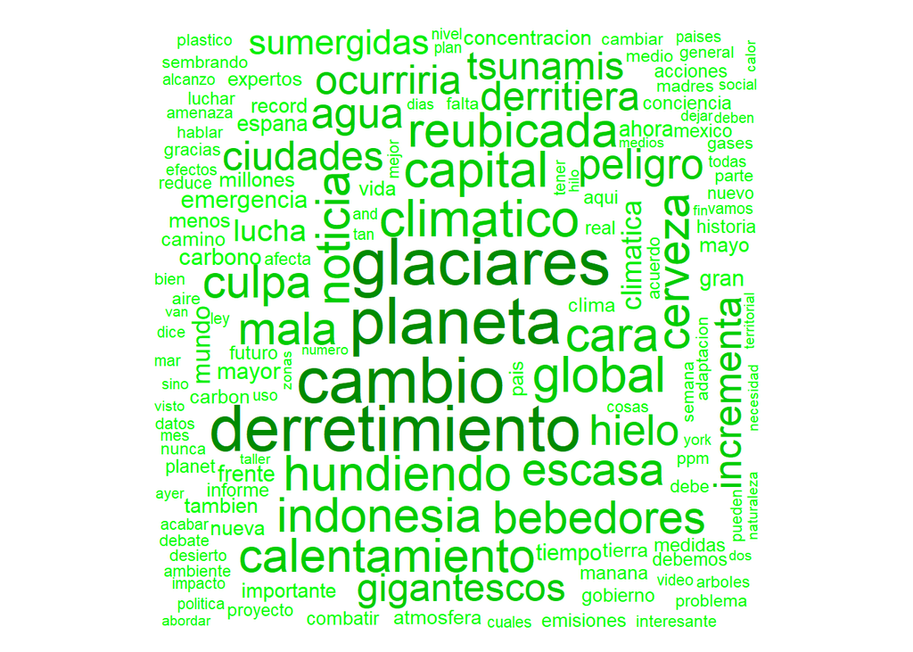

```r
wordcloud(names(freq), freq, scale = c(3,0.5), max.words = 200, random.order = FALSE, colors = c("green1","green2","green3","green4"))
```

Ahora para poder guardarlo, recurriremos al paquete **wordcloud2**:

```r
wc1 <- wordcloud2(freq.data.frame, color = "random-dark")
wc1
```

[interactive chart not shown]

```r
saveWidget(wc1,"wc1.html",selfcontained = FALSE,title = "WordCloud 1")
```

El paquete **wordcloud2** nos permite una mayor customización a la hora de presentar las palabras. Por ejemplo, podemos crear wordclouds dentro de figuras:

```r
wcPentagon <- wordcloud2(freq.data.frame, color = "random-dark", shape = "pentagon")
saveWidget(wcPentagon,"wcPentagon.html",selfcontained = FALSE,title = "WordCloud Pentagon")
```

Por ultimo, también podemos crear wordclouds dentro de imagenes:

```r
iceberg <- wordcloud2(freq.data.frame, figPath = "iceberg.png", size = 1.5, color = "skyblue")
saveWidget(iceberg,"iceberg.html",selfcontained = FALSE,title = "WordCloud Iceberg")
```

# 2 Buscar relaciones

Procedemos a coger los 5 términos más frecuentes y a ver con que otros términos están relacionados:

```r
top.terms <- as.vector(head(freq.data.frame$name,5))
assocs <- findAssocs(dtm, terms = top.terms, corlimit = 0.25)
assocs <- unlist(assocs)
assocs.data.frame <- data.frame(asociacion = names(assocs), satisfacion = assocs)
row.names(assocs.data.frame) <- c(1:nrow(assocs.data.frame))
assocs.data.frame
```

```
##                   asociacion satisfacion
## 1         planeta.derritiera        0.73
## 2          planeta.ocurriria        0.73
## 3              planeta.hielo        0.70
## 4      glaciares.gigantescos        0.70
## 5       glaciares.incrementa        0.70
## 6         glaciares.tsunamis        0.70
## 7          glaciares.peligro        0.66
## 8       glaciares.sumergidas        0.66
## 9         glaciares.ciudades        0.60
## 10            glaciares.agua        0.58
## 11 derretimiento.gigantescos        0.71
## 12  derretimiento.incrementa        0.71
## 13    derretimiento.tsunamis        0.71
## 14  derretimiento.sumergidas        0.67
## 15     derretimiento.peligro        0.66
## 16    derretimiento.ciudades        0.61
## 17        derretimiento.agua        0.59
```

# 3 Dispositivos usados

```r
encodeSource <- function(x) {
  if(x=="<a href=\"http://twitter.com/download/iphone\" rel=\"nofollow\">Twitter for iPhone</a>"){
    gsub("<a href=\"http://twitter.com/download/iphone\" rel=\"nofollow\">Twitter for iPhone</a>", "iphone", x,fixed=TRUE)
  }else if(x=="<a href=\"http://twitter.com/#!/download/ipad\" rel=\"nofollow\">Twitter for iPad</a>"){
    gsub("<a href=\"http://twitter.com/#!/download/ipad\" rel=\"nofollow\">Twitter for iPad</a>","ipad",x,fixed=TRUE)
  }else if(x=="<a href=\"http://twitter.com/download/android\" rel=\"nofollow\">Twitter for Android</a>"){
    gsub("<a href=\"http://twitter.com/download/android\" rel=\"nofollow\">Twitter for Android</a>","android",x,fixed=TRUE)
  } else if(x=="<a href=\"http://twitter.com\" rel=\"nofollow\">Twitter Web Client</a>"){
    gsub("<a href=\"http://twitter.com\" rel=\"nofollow\">Twitter Web Client</a>","Web",x,fixed=TRUE)
  } else if(x=="<a href=\"http://www.twitter.com\" rel=\"nofollow\">Twitter for Windows Phone</a>"){
    gsub("<a href=\"http://www.twitter.com\" rel=\"nofollow\">Twitter for Windows Phone</a>","windows phone",x,fixed=TRUE)
  }else if(x=="<a href=\"http://dlvr.it\" rel=\"nofollow\">dlvr.it</a>"){
    gsub("<a href=\"http://dlvr.it\" rel=\"nofollow\">dlvr.it</a>","dlvr.it",x,fixed=TRUE)
  }else if(x=="<a href=\"http://ifttt.com\" rel=\"nofollow\">IFTTT</a>"){
    gsub("<a href=\"http://ifttt.com\" rel=\"nofollow\">IFTTT</a>","ifttt",x,fixed=TRUE)
  }else if(x=="<a href=\"http://earthquaketrack.com\" rel=\"nofollow\">EarthquakeTrack.com</a>"){
    gsub("<a href=\"http://earthquaketrack.com\" rel=\"nofollow\">EarthquakeTrack.com</a>","earthquaketrack",x,fixed=TRUE)
  }else if(x=="<a href=\"http://www.didyoufeel.it/\" rel=\"nofollow\">Did You Feel It</a>"){
    gsub("<a href=\"http://www.didyoufeel.it/\" rel=\"nofollow\">Did You Feel It</a>","did_you_feel_it",x,fixed=TRUE)
  }else if(x=="<a href=\"http://www.mobeezio.com/apps/earthquake\" rel=\"nofollow\">Earthquake Mobile</a>"){
    gsub("<a href=\"http://www.mobeezio.com/apps/earthquake\" rel=\"nofollow\">Earthquake Mobile</a>","earthquake_mobile",x,fixed=TRUE)
  }else if(x=="<a href=\"http://www.facebook.com/twitter\" rel=\"nofollow\">Facebook</a>"){
    gsub("<a href=\"http://www.facebook.com/twitter\" rel=\"nofollow\">Facebook</a>","facebook",x,fixed=TRUE)
  }else {
    "others"
  }
}
```

Creamos una nueva columna en el dataframe que recoja los dispositivos desde los que se haya mandado el tweet:

```r
tweets.data.frame$tweetSource = sapply(tweets.data.frame$statusSource, function(sourceSystem) encodeSource(sourceSystem))
```

Dado que son muchos tweets vamos a crear una gráfica para poder observarlo:

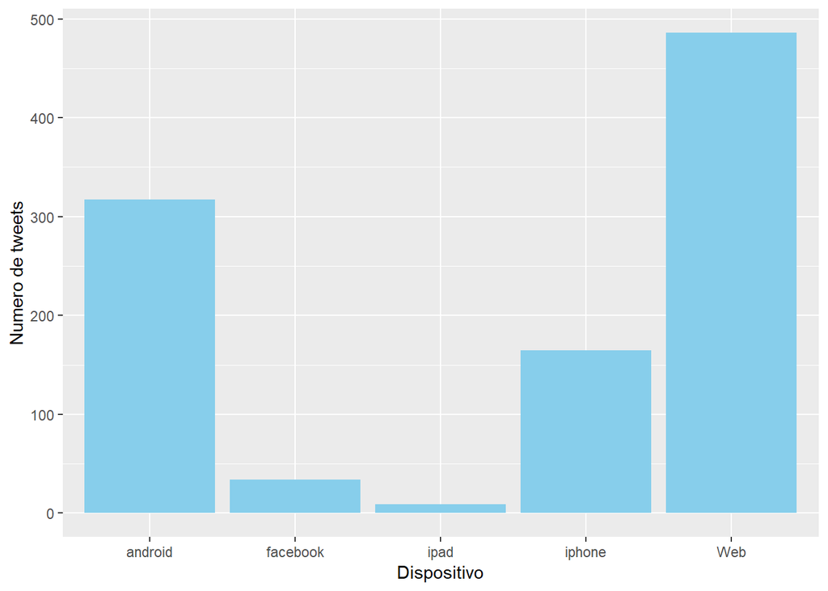

```r
ggplot(tweets.data.frame[tweets.data.frame$tweetSource != "others",], aes(tweetSource)) + geom_bar(fill = "skyblue") + ylab("Numero de tweets") + xlab("Dispositivo")
```

Por último, vamos a obtener la palabra que más veces aparece en nuestro wordcloud. En nuestro caso esta palabra es:

```r
most.common.term <- as.vector(freq.data.frame[1,]$name)
most.common.term
```

```
## [1] "planeta"
```

Grabamos ahora en un dataframe los tweets en los que aparece dicho término. Las columnas del dataframe serán término, usuario y texto del tweet:

```r
term.data.frame <- select(filter(tweets.data.frame, stringr::str_detect(tweets.data.frame$text, most.common.term)), text, screenName)
term.data.frame <- mutate(term.data.frame, most.common.term)
term.data.frame
```

```
##                                                                                                                                        text
## 1                                     La ONU muestra en imagenes en este hilo el impacto del   en tiempo real en nuestro planeta Y conclu
## 2                                 Interesante hilo de la   sobre los efectos del   en nuestro planeta visto desde el espacio 👇
## 3                                                                             La   aumentara su vigilancia de la   climatica del planeta
## 4                                                   El verano esta llegando y el planeta se esta yendo para no volver asi q espabilemos
## 5                                         No hay planeta B la ONU explica por que cambiar nuestra actitud con la Tierra 🌍  via
## 6                                                        No hay planeta B  gt interesantes reflexiones hoy en el portal   via      Nuestr
## 7                          🌍Entendemos la necesidad urgente de abordar el   y proteger nuestro planeta El Reino Unido esta tom
## 8                        El calor y la contingencia ambiental son los primeros problemas por acabar con los recursos del planetaLa tala d
## 9                                  Hoy mas de 280 especialistas nos encontramos en   porque creemos que salvar la   y proteger el planeta
## 10 Y los volcanes Y el Totolqueme Asi la atmosfera en San Martin y todo Puebla 😭😫🤯 nuestro planeta sufre
## 11                        Aun estamos a tiempo pa  rescatar el planeta Sin las politicas adecuadas y una sociedad consciente sera dificil
## 12                          Nunca antes en la historia del Homo sapiens el planeta habia tenido un nivel tan alto de  Los expertos ruegan
## 13                      Sanitarios por el planeta  Llamamiento mundial exhorta a estos profesionales a actuar sobre la salud planetaria d
## 14                    Es la primera vez en la historia del ser humano que la atmosfera de nuestro planeta ha registrado mas de 415 partes
```

[output cut: 161 more lines]

## 3.1 Conclusiones

Como podemos ver en muchos de los ejemplos imprimidos, esta labor de estudio necesita de una profunda preparación con el objetivo de limpiar la lista de tweets que hayan sido publicados por bots por ejemplo y que no tengan ningún tipo de relevancia para el estudio.